# Predição do Campeonato Brasileiro 2026 por Monte Carlo

Laboratório 1 — ME524, Unicamp (2026)

Arthur Agostinho Furlan Teixeira, RA: 164363

Caio Frare, RA: 242578

João Paulo de Castro Alves, RA: 256481

2026-09-23

# 1 Introdução

Este relatório estima a força de ataque ($\theta$) e defesa ($\phi$) de cada time do Campeonato Brasileiro 2026 a partir dos jogos já disputados, simula os jogos pendentes segundo o modelo de gols por Poisson do enunciado e usa as simulações para responder às perguntas do laboratório (ver `docs/enunciado.md`). As decisões de modelagem dadas pelo enunciado estão documentadas como ADRs em `.ai/modelagem.md`; este relatório segue essas decisões e só implementa o que está em aberto para o grupo (a atividade extra, na última seção).

O código usa exclusivamente as funções do pacote (`R/*.R`), já testadas em `tests/testthat/`; nenhuma lógica de estimação, simulação ou classificação é reimplementada aqui.

# 2 Preparação dos dados

```r
jogos <- carregar_jogos("../data/raw/brasileirao_2026.csv")
disputados <- jogos_disputados(jogos)
pendentes <- jogos_pendentes(jogos)

cat("Jogos disputados:", nrow(disputados), "| pendentes:", nrow(pendentes), "\n")
```

```
## Jogos disputados: 278 | pendentes: 102
```

```r
range(table(c(disputados$time_mandante, disputados$time_visitante)))
```

```
## [1] 27 29
```

Os 20 times não têm exatamente o mesmo número de jogos disputados (algumas rodadas ainda estão incompletas), então $\theta$/$\phi$ comparam times com bases amostrais um pouco diferentes. Como são médias *por jogo*, isso não enviesa a estimativa, só afeta a precisão relativa entre times (ver intervalos de confiança na seção de bootstrap).

# 3 Estimação de $\theta$ e $\phi$

```r
parametros <- estimar_parametros(disputados)
head(parametros)
```

```
##                 theta      phi
## Athletico-PR 1.535714 1.142857
## Atlético-MG  1.333333 1.185185
## Bahia        1.535714 1.250000
## Botafogo     1.464286 1.607143
## Bragantino   1.250000 1.142857
## Chapecoense  1.074074 1.962963
```

## 3.1 Limitação: o modelo não tem vantagem de mandante

$\theta$ e $\phi$ (ADR-002) misturam jogos em casa e fora, então o time nasce sem vantagem de jogar em casa. Nos jogos já disputados isso não é o que se observa:

```r
disputados %>%
  summarise(
    gols_mandante_medio = mean(gols_mandante),
    gols_visitante_medio = mean(gols_visitante),
    vitoria_mandante = mean(gols_mandante > gols_visitante),
    empate = mean(gols_mandante == gols_visitante),
    vitoria_visitante = mean(gols_mandante < gols_visitante)
  )
```

```
##   gols_mandante_medio gols_visitante_medio vitoria_mandante    empate
## 1            1.514388             1.154676        0.4640288 0.2769784
##   vitoria_visitante
## 1         0.2589928
```

# 4 Classificação atual

`calcular_classificacao()` (já implementada e testada em `R/classificacao.R`) serve tanto para a tabela atual quanto, dentro do laço de Monte Carlo, para cada temporada simulada.

```r
tabela_atual <- calcular_classificacao(disputados)
tabela_atual[, c("posicao", "pontos", "vitorias", "saldo_gols", "gols_marcados")]
```

```
##               posicao pontos vitorias saldo_gols gols_marcados
## Flamengo            1     57       17         30            54
## Palmeiras           2     57       16         26            47
## Athletico-PR        3     49       14         11            43
## Fluminense          4     48       13          8            44
## Bahia               5     46       12          8            43
## Cruzeiro            6     45       13          2            42
## Atlético-MG         7     40       11          4            36
## Bragantino          8     39       11          3            35
## Santos              9     38       10          1            41
## Coritiba           10     38       10         -6            37
## São Paulo          11     36       10          2            32
## Corinthians        12     35        9         -1            30
## Botafogo           13     35        9         -4            41
## Grêmio             14     32        8         -6            31
## Mirassol           15     32        8        -10            34
## Vasco              16     31        8         -7            34
## Vitória            17     30        8        -16            27
## Internacional      18     28        6         -6            30
## Remo               19     23        5        -15            32
## Chapecoense        20     18        3        -24            29
```

# 5 Simulação de uma temporada

```r
temporada_exemplo <- simular_temporada(pendentes, parametros, seed = 1)
head(temporada_exemplo)
```

```
##     rodada time_mandante gols_mandante time_visitante gols_visitante
## 208     21     São Paulo             1         Santos              1
## 209     21   Atlético-MG             1     Bragantino              5
## 210     21   Chapecoense             1          Vasco              2
## 282     29 Internacional             3    Corinthians              0
## 283     29          Remo             0         Grêmio              0
## 284     29       Vitória             3    Chapecoense              1
```

# 6 Simulação Monte Carlo

Para cada uma das $N$ réplicas: simula os jogos pendentes (`simular_temporada()`), junta com os jogos já disputados e calcula a classificação final (`calcular_classificacao()`). Guardamos só o essencial por réplica: pontos e posição final de cada time, e se houve empate em pontos no topo da tabela.

```r
N <- 10000
set.seed(524)

times <- rownames(parametros)
pontos_mat <- matrix(0, nrow = N, ncol = length(times), dimnames = list(NULL, times))
posicao_mat <- matrix(0L, nrow = N, ncol = length(times), dimnames = list(NULL, times))
empate_topo <- logical(N)

for (r in seq_len(N)) {
  simulados <- simular_temporada(pendentes, parametros, seed = r)
  tabela <- calcular_classificacao(rbind(disputados, simulados))

  pontos_mat[r, ] <- tabela[times, "pontos"]
  posicao_mat[r, ] <- tabela[times, "posicao"]
  empate_topo[r] <- sum(tabela$pontos == max(tabela$pontos)) > 1
}
```

# 7 Classificação esperada após a simulação

Consolidando as 10.000 réplicas em uma única tabela: pontos médios, posição média e as probabilidades de título e rebaixamento de cada time (as mesmas das perguntas 1 e 2, lado a lado). A ordenação é pela posição média, não é a classificação de uma réplica específica, é a média sobre todas elas.

```r
# Os nomes dos times vem das colunas de pontos_mat/posicao_mat (colMeans()
# preserva os nomes das colunas), igual a calcular_classificacao() -- por
# isso, como em `tabela_atual`, o time aparece só como nome de linha, sem
# uma coluna repetida.
classificacao_simulada <- data.frame(
  pontos_medios = round(colMeans(pontos_mat), 1),
  posicao_media = round(colMeans(posicao_mat), 1),
  p_campeao = colMeans(posicao_mat == 1),
  p_rebaixado = colMeans(posicao_mat >= 17)
) %>%
  arrange(posicao_media) %>%
  mutate(posicao = row_number(), .before = pontos_medios)

classificacao_simulada
```

```
##               posicao pontos_medios posicao_media p_campeao p_rebaixado
## Flamengo            1          74.2           1.5    0.5456      0.0000
## Palmeiras           2          73.8           1.7    0.4339      0.0000
## Athletico-PR        3          64.2           3.9    0.0129      0.0000
## Fluminense          4          63.1           4.4    0.0063      0.0000
## Bahia               5          60.3           5.6    0.0010      0.0000
## Cruzeiro            6          59.0           6.0    0.0002      0.0000
## Atlético-MG         7          55.3           8.0    0.0001      0.0006
## Bragantino          8          53.4           8.8    0.0000      0.0020
## Santos              9          52.6           9.6    0.0000      0.0060
## São Paulo          10          51.6          10.0    0.0000      0.0116
## Coritiba           11          50.4          11.2    0.0000      0.0196
## Corinthians        12          49.0          11.9    0.0000      0.0464
## Botafogo           13          48.8          12.0    0.0000      0.0511
## Vasco              14          45.3          14.2    0.0000      0.2074
## Grêmio             15          44.7          14.6    0.0000      0.2466
## Mirassol           16          43.3          15.5    0.0000      0.3736
## Vitória            17          41.9          16.1    0.0000      0.4977
## Internacional      18          41.3          16.5    0.0000      0.5852
## Remo               19          34.9          18.7    0.0000      0.9553
## Chapecoense        20          29.7          19.8    0.0000      0.9969
```

# 8 Pergunta 1 — Probabilidade de cada time ser campeão

```r
erro_mc <- function(p, n) sqrt(p * (1 - p) / n)

p_campeao <- colMeans(posicao_mat == 1)

resultado_q1 <- data.frame(
  time = times,
  p_campeao = p_campeao,
  erro_mc = erro_mc(p_campeao, N)
) %>% arrange(desc(p_campeao))

resultado_q1
```

```
##                        time p_campeao      erro_mc
## Flamengo           Flamengo    0.5456 0.0049791630
## Palmeiras         Palmeiras    0.4339 0.0049561153
## Athletico-PR   Athletico-PR    0.0129 0.0011284321
## Fluminense       Fluminense    0.0063 0.0007912212
## Bahia                 Bahia    0.0010 0.0003160696
## Cruzeiro           Cruzeiro    0.0002 0.0001414072
## Atlético-MG     Atlético-MG    0.0001 0.0000999950
## Botafogo           Botafogo    0.0000 0.0000000000
## Bragantino       Bragantino    0.0000 0.0000000000
## Chapecoense     Chapecoense    0.0000 0.0000000000
## Corinthians     Corinthians    0.0000 0.0000000000
## Coritiba           Coritiba    0.0000 0.0000000000
## Grêmio               Grêmio    0.0000 0.0000000000
## Internacional Internacional    0.0000 0.0000000000
## Mirassol           Mirassol    0.0000 0.0000000000
## Remo                   Remo    0.0000 0.0000000000
## Santos               Santos    0.0000 0.0000000000
## São Paulo         São Paulo    0.0000 0.0000000000
## Vasco                 Vasco    0.0000 0.0000000000
## Vitória             Vitória    0.0000 0.0000000000
```

# 9 Pergunta 2 — Probabilidade de cada time ser rebaixado

O enunciado rebaixa os 4 últimos colocados, ou seja, posições 17 a 20.

```r
p_rebaixado <- colMeans(posicao_mat >= 17)

resultado_q2 <- data.frame(
  time = times,
  p_rebaixado = p_rebaixado,
  erro_mc = erro_mc(p_rebaixado, N)
) %>% arrange(desc(p_rebaixado))

resultado_q2
```

```
##                        time p_rebaixado      erro_mc
## Chapecoense     Chapecoense      0.9969 0.0005559128
## Remo                   Remo      0.9553 0.0020664440
## Internacional Internacional      0.5852 0.0049268749
## Vitória             Vitória      0.4977 0.0049999471
## Mirassol           Mirassol      0.3736 0.0048375928
## Grêmio               Grêmio      0.2466 0.0043103183
## Vasco                 Vasco      0.2074 0.0040544450
## Botafogo           Botafogo      0.0511 0.0022020170
## Corinthians     Corinthians      0.0464 0.0021034980
## Coritiba           Coritiba      0.0196 0.0013862121
## São Paulo         São Paulo      0.0116 0.0010707679
## Santos               Santos      0.0060 0.0007722694
## Bragantino       Bragantino      0.0020 0.0004467662
## Atlético-MG     Atlético-MG      0.0006 0.0002448755
## Athletico-PR   Athletico-PR      0.0000 0.0000000000
## Bahia                 Bahia      0.0000 0.0000000000
## Cruzeiro           Cruzeiro      0.0000 0.0000000000
## Flamengo           Flamengo      0.0000 0.0000000000
## Fluminense       Fluminense      0.0000 0.0000000000
## Palmeiras         Palmeiras      0.0000 0.0000000000
```

Quando `p_rebaixado` é 0 ou 1 em todas as `N` réplicas, o erro Monte Carlo acima também sai 0; isso não significa certeza, só que o evento não ocorreu (ou sempre ocorreu) nas réplicas rodadas. Para esses casos um limite superior mais honesto é $3/N$ (regra de três para zero eventos em `N` tentativas de Bernoulli).

# 10 Pergunta 3 — Probabilidade de decisão por critério de desempate

“Decidido pelos critérios de desempate” pode significar (a) o título saiu empatado em pontos no topo, ou (b) *alguma* posição relevante (título ou última vaga de rebaixamento) saiu empatada em pontos. **Decisão do grupo:** adotamos a leitura (a), a pergunta se refere ao desempate que decide o título como resposta oficial; a leitura (b) fica calculada abaixo só como referência.

```r
p_empate_topo <- mean(empate_topo)

posicoes_ordenadas_por_pontos <- t(apply(pontos_mat, 1, function(p) sort(p, decreasing = TRUE)))
empate_16_17 <- posicoes_ordenadas_por_pontos[, 16] == posicoes_ordenadas_por_pontos[, 17]
p_empate_rebaixamento <- mean(empate_16_17)

data.frame(
  interpretacao = c("Empate no título (posição 1) — resposta oficial (a)", "Empate na última vaga de rebaixamento (16º-17º) — referência (b)"),
  probabilidade = c(p_empate_topo, p_empate_rebaixamento),
  erro_mc = erro_mc(c(p_empate_topo, p_empate_rebaixamento), N)
)
```

```
##                                                      interpretacao
## 1              Empate no título (posição 1) — resposta oficial (a)
## 2 Empate na última vaga de rebaixamento (16º-17º) — referência (b)
##   probabilidade     erro_mc
## 1        0.0684 0.002524311
## 2        0.2000 0.004000000
```

A probabilidade de o título ser decidido pelos critérios de desempate é **6.8%** (erro MC ±0.25 p.p.).

# 11 Pergunta 4 — Valor esperado de pontos do campeão

```r
pontos_campeao <- pontos_mat[posicao_mat == 1]
stopifnot(length(pontos_campeao) == N) # exatamente um campeao por replica

media_pontos_campeao <- mean(pontos_campeao)
erro_mc_media <- sd(pontos_campeao) / sqrt(N)
intervalo_predicao <- quantile(pontos_campeao, c(0.025, 0.975))

cat("Média de pontos do campeão:", media_pontos_campeao, "\n")
```

```
## Média de pontos do campeão: 76.5055
```

```r
cat("Erro Monte Carlo da média:", erro_mc_media, "\n")
```

```
## Erro Monte Carlo da média: 0.03221523
```

```r
cat("Intervalo de predição 95% (entre réplicas):", intervalo_predicao, "\n")
```

```
## Intervalo de predição 95% (entre réplicas): 70 83
```

O erro Monte Carlo acima é sobre a *média*; o intervalo de predição descreve a variabilidade dos pontos do campeão *entre réplicas*.

# 12 Pergunta 5 — Pontos para ≥90% de chance de título

Igual à pergunta 3, adotamos duas leituras possíveis:

## 12.1 Leitura A — menor pontuação que garante ≥90% empiricamente

Para cada valor de pontos observado nas simulações, calculamos a proporção de vezes em que esse valor correspondeu ao campeão (olhando todos os times em todas as posições). Como essa proporção não é estritamente monótona (ruído de simulação, principalmente nos extremos com poucas observações), usamos o menor valor de pontos a partir do qual **todos** os valores maiores também têm proporção ≥ 90%.

```r
pontos_vetor <- as.vector(pontos_mat)
campeao_vetor <- as.vector(posicao_mat == 1)

prop_campeao_por_pontos <- tapply(campeao_vetor, pontos_vetor, mean)
n_por_pontos <- tapply(campeao_vetor, pontos_vetor, length)
valores_pontos <- sort(unique(pontos_vetor))

acima_do_limiar <- vapply(valores_pontos, function(x) {
  chave <- as.character(valores_pontos[valores_pontos >= x])
  all(prop_campeao_por_pontos[chave] >= 0.90)
}, logical(1))

pontos_90_titulo_a <- min(valores_pontos[acima_do_limiar])
cat("Leitura A — pontos para >=90% de chance de título:", pontos_90_titulo_a, "\n")
```

```
## Leitura A — pontos para >=90% de chance de título: 79
```

```r
data.frame(
  pontos = valores_pontos,
  prop_campeao = as.numeric(prop_campeao_por_pontos),
  n = as.numeric(n_por_pontos)
) %>% arrange(desc(prop_campeao))
```

```
##    pontos prop_campeao    n
## 1      85  1.000000000   71
## 2      87  1.000000000   12
## 3      83  0.993865031  163
## 4      84  0.987654321   81
## 5      82  0.971751412  354
## 6      81  0.968446602  412
## 7      80  0.956636005  761
## 8      79  0.911266201 1003
## 9      78  0.855624446 1129
## 10     77  0.789699571 1631
## 11     76  0.694652099 1739
## 12     75  0.583693305 1852
## 13     74  0.475956820 2038
## 14     73  0.358490566 1961
```

[output cut: 55 more lines]

## 12.2 Leitura B — percentil 90 da pontuação do vice-campeão

Outra forma de responder: que pontuação supera o 2º colocado em 90% das réplicas? Aqui olhamos só a distribuição de pontos de quem terminou em 2º lugar, não a de todos os times em todas as posições.

```r
pontos_vice <- pontos_mat[posicao_mat == 2]
pontos_90_titulo_b <- as.numeric(quantile(pontos_vice, 0.90))
cat("Leitura B — percentil 90 da pontuação do vice-campeão:", pontos_90_titulo_b, "\n")
```

```
## Leitura B — percentil 90 da pontuação do vice-campeão: 76
```

As duas leituras dão respostas próximas, mas diferentes (79 vs. 76 pontos), porque respondem perguntas ligeiramente distintas.

# 13 Pergunta 6 — Pontos para ≥95% de chance de escapar do rebaixamento

Mesma ambiguidade da pergunta 5, mesmo tratamento: duas leituras.

## 13.1 Leitura A — menor pontuação que garante ≥95% empiricamente

Mesma lógica da leitura A da pergunta 5, trocando “foi campeão” por “não foi rebaixado” (posição < 17) e o limiar para 95%.

```r
nao_rebaixado_vetor <- as.vector(posicao_mat < 17)

prop_permanencia_por_pontos <- tapply(nao_rebaixado_vetor, pontos_vetor, mean)

acima_do_limiar_perm <- vapply(valores_pontos, function(x) {
  chave <- as.character(valores_pontos[valores_pontos >= x])
  all(prop_permanencia_por_pontos[chave] >= 0.95)
}, logical(1))

pontos_95_permanencia_a <- min(valores_pontos[acima_do_limiar_perm])
cat("Leitura A — pontos para >=95% de chance de não ser rebaixado:", pontos_95_permanencia_a, "\n")
```

```
## Leitura A — pontos para >=95% de chance de não ser rebaixado: 45
```

## 13.2 Leitura B — percentil 95 da pontuação do 17º colocado

```r
pontos_17 <- pontos_mat[posicao_mat == 17]
pontos_95_permanencia_b <- as.numeric(quantile(pontos_17, 0.95))
cat("Leitura B — percentil 95 da pontuação do 17º colocado:", pontos_95_permanencia_b, "\n")
```

```
## Leitura B — percentil 95 da pontuação do 17º colocado: 44
```

# 14 Variabilidade das estimativas: bootstrap de $\theta$ e $\phi$

Para cada time, reamostramos com reposição os jogos que ele disputou (`bootstrap_parametros()`, ADR-003) e recalculamos $\theta$/$\phi$ em cada reamostragem. O intervalo de confiança usado é o de percentis 2,5%–97,5% (`intervalo_confianca()`).

```r
set.seed(2024)
B <- 1000
amostras_bootstrap <- bootstrap_parametros(disputados, n_reamostragens = B, seed = 2024)

ic_por_time <- amostras_bootstrap %>%
  group_by(time) %>%
  summarise(
    theta_medio = mean(theta),
    theta_li = intervalo_confianca(theta)[1],
    theta_ls = intervalo_confianca(theta)[2],
    phi_medio = mean(phi),
    phi_li = intervalo_confianca(phi)[1],
    phi_ls = intervalo_confianca(phi)[2]
  )

ic_por_time
```

```
## # A tibble: 20 × 7
##    time          theta_medio theta_li theta_ls phi_medio phi_li phi_ls
##    <chr>               <dbl>    <dbl>    <dbl>     <dbl>  <dbl>  <dbl>
##  1 Athletico-PR        1.53     1.14      1.93     1.15   0.786   1.57
##  2 Atlético-MG         1.34     0.889     1.81     1.19   0.815   1.59
##  3 Bahia               1.55     1.21      1.86     1.27   0.892   1.68
##  4 Botafogo            1.46     1.04      1.93     1.60   1.18    2.04
##  5 Bragantino          1.25     0.893     1.64     1.14   0.821   1.46
##  6 Chapecoense         1.06     0.704     1.44     1.96   1.56    2.37
##  7 Corinthians         1.08     0.75      1.46     1.10   0.714   1.5
##  8 Coritiba            1.32     0.929     1.68     1.54   1.11    2
##  9 Cruzeiro            1.50     1.14      1.86     1.42   1       1.86
## 10 Flamengo            1.92     1.5       2.36     0.864  0.536   1.21
## 11 Fluminense          1.58     1.25      1.93     1.29   0.964   1.61
## 12 Grêmio              1.12     0.75      1.54     1.33   0.964   1.68
## 13 Internacional       1.08     0.714     1.46     1.28   0.929   1.64
## 14 Mirassol            1.17     0.897     1.45     1.51   1.17    1.90
## 15 Palmeiras           1.66     1.21      2.14     0.746  0.464   1.04
## 16 Remo                1.14     0.786     1.57     1.68   1.32    2.07
## 17 Santos              1.52     1.19      1.81     1.48   1.07    1.93
## 18 São Paulo           1.19     0.889     1.56     1.11   0.815   1.37
## 19 Vasco               1.25     0.815     1.70     1.52   1.15    1.93
## 20 Vitória             0.966    0.643     1.32     1.56   1.04    2.11
```

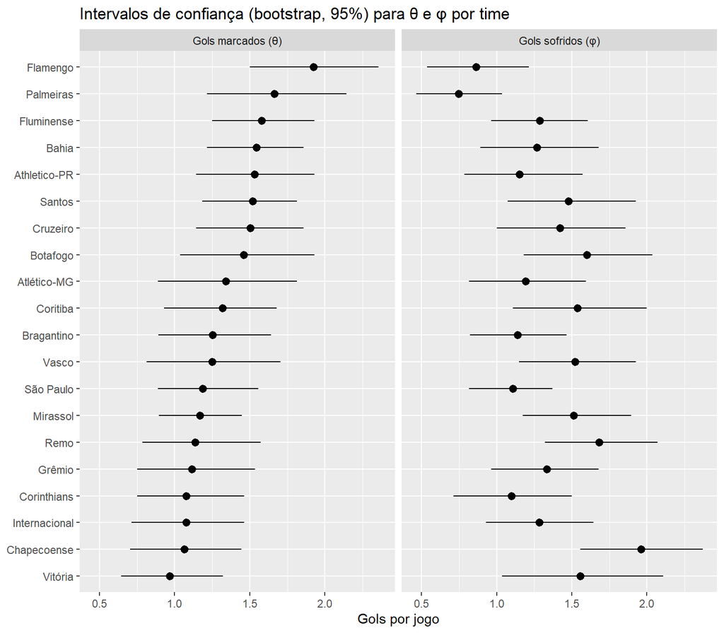

```r
grafico_dados <- ic_por_time %>%
  select(
    time,
    marcados_medio = theta_medio, marcados_li = theta_li, marcados_ls = theta_ls,
    sofridos_medio = phi_medio, sofridos_li = phi_li, sofridos_ls = phi_ls
  ) %>%
  pivot_longer(
    cols = -time,
    names_to = c("tipo", ".value"),
    names_pattern = "(marcados|sofridos)_(medio|li|ls)"
  )

ordem_times <- ic_por_time$time[order(ic_por_time$theta_medio)]
grafico_dados$time <- factor(grafico_dados$time, levels = ordem_times)

ggplot(grafico_dados, aes(x = time, y = medio, ymin = li, ymax = ls)) +
  geom_pointrange() +
  coord_flip() +
  facet_wrap(~tipo, labeller = as_labeller(c(marcados = "Gols marcados (θ)", sofridos = "Gols sofridos (φ)"))) +
  labs(x = NULL, y = "Gols por jogo", title = "Intervalos de confiança (bootstrap, 95%) para θ e φ por time")
```

Com ~27–29 jogos por time, os intervalos de confiança são relativamente largos, vale discutir quais times têm as estimativas mais instáveis (IC mais largo) e o que isso significa para a confiabilidade das respostas 1 e 2. Importante: essa incerteza **não propaga** para a simulação Monte Carlo da seção anterior. Lá, $\theta$/$\phi$ entram como constantes conhecidas, então `p_campeao`/`p_rebaixado` carregam só erro Monte Carlo, não erro de estimação. Propagar exigiria reestimar $\theta$/$\phi$ a cada réplica (fora do escopo pedido pelo enunciado).

# 15 Atividade extra

(ver ADR-004 em `.ai/modelagem.md`)

A limitação mais evidente, medida acima, é a ausência de vantagem de mandante: o mandante marca em média 1.51 gols/jogo contra 1.15 do visitante, mas o modelo do enunciado gera $\lambda$ parecidos para os dois lados. Uma proposta simples e barata de implementar (um fator multiplicativo único aplicado aos $\lambda$ de mandante/visitante) preservaria o resto do pipeline sem alterações; alternativas mais custosas (θ/φ separados por condição de mandante/visitante) reduzem a base amostral por parâmetro pela metade e merecem ser cruzadas com os IC da seção de bootstrap antes de adotadas.

Uma forma de calibrar esse fator diretamente pelos dados: escolher $h$ tal que a razão entre os $\lambda$ ajustados reproduza a razão observada entre gols de mandante e de visitante nos jogos já disputados.

$$h = \sqrt{\dfrac{\text{gols mandante (média)}}{\text{gols visitante
(média)}}}$$

```r
h <- sqrt(mean(disputados$gols_mandante) / mean(disputados$gols_visitante))
cat("h =", round(h, 3), "\n")
```

```
## h = 1.145
```

Com esse $h$, os $\lambda$ da simulação (ADR-001 em `.ai/modelagem.md`) passam de `(theta_mandante + phi_visitante) / 2` e `(theta_visitante + phi_mandante) / 2` para `lambda_mandante * h` e `lambda_visitante / h`. **Implementado** como o argumento opcional `h` de `simular_jogo()`/`simular_temporada()` (`R/simulacao.R`), com `h = 1` como padrão, por isso as perguntas 1 a 6 acima, que não passam `h`, continuam usando exatamente o modelo original do enunciado.

## 15.2 Simulação com o fator de mandante

Repetimos a simulação Monte Carlo (mesmo `N`, mesmos seeds por réplica, só a etapa `simular_temporada()` passa a receber `h`) para medir o efeito da calibração nas respostas 1 e 2:

```r
pontos_mat_h <- matrix(0, nrow = N, ncol = length(times), dimnames = list(NULL, times))
posicao_mat_h <- matrix(0L, nrow = N, ncol = length(times), dimnames = list(NULL, times))

for (r in seq_len(N)) {
  simulados_h <- simular_temporada(pendentes, parametros, seed = r, h = h)
  tabela_h <- calcular_classificacao(rbind(disputados, simulados_h))

  pontos_mat_h[r, ] <- tabela_h[times, "pontos"]
  posicao_mat_h[r, ] <- tabela_h[times, "posicao"]
}

p_campeao_h <- colMeans(posicao_mat_h == 1)
p_rebaixado_h <- colMeans(posicao_mat_h >= 17)
```

Comparação para os times com maior chance de título (pergunta 1, modelo original):

```r
# Os nomes dos times vem das colunas indexadas por nome (p_campeao[...]),
# igual a `classificacao_simulada` -- por isso, sem uma coluna `time`
# redundante, o time aparece só como nome de linha.
times_campeao <- names(sort(p_campeao, decreasing = TRUE))[1:6]

data.frame(
  p_campeao_original = p_campeao[times_campeao],
  p_campeao_com_h = p_campeao_h[times_campeao]
) %>% arrange(desc(p_campeao_original))
```

```
##              p_campeao_original p_campeao_com_h
## Flamengo                 0.5456          0.5186
## Palmeiras                0.4339          0.4623
## Athletico-PR             0.0129          0.0121
## Fluminense               0.0063          0.0056
## Bahia                    0.0010          0.0009
## Cruzeiro                 0.0002          0.0003
```

E para os times com maior chance de rebaixamento (pergunta 2, modelo original):

```r
times_rebaixado <- names(sort(p_rebaixado, decreasing = TRUE))[1:6]

data.frame(
  p_rebaixado_original = p_rebaixado[times_rebaixado],
  p_rebaixado_com_h = p_rebaixado_h[times_rebaixado]
) %>% arrange(desc(p_rebaixado_original))
```

```
##               p_rebaixado_original p_rebaixado_com_h
## Chapecoense                 0.9969            0.9965
## Remo                        0.9553            0.9535
## Internacional               0.5852            0.5848
## Vitória                     0.4977            0.4910
## Mirassol                    0.3736            0.3929
## Grêmio                      0.2466            0.2308
```

## 15.3 Outra melhoria no modelo: desfalques por suspensão/lesão

Uma limitação que o fator $h$ não resolve, e que também não está implementada, é que o modelo trata cada time como se tivesse sempre seu elenco completo disponível. Times reais perdem jogadores-chave por cartão (suspensão) ou contusão de uma rodada para outra, o que muda sua força ofensiva/defensiva pontualmente, algo que θ/ϕ (médias sobre todos os jogos já disputados) não capturam. Incorporar isso exigiria dados que o CSV atual (`data/raw/brasileirao_2026.csv`, só placares) não tem, escalação ou lista de desfalques por rodada, e uma forma de traduzir “fulano está fora” em um ajuste de $\lambda$ (ex.: um multiplicador por time e rodada, proporcional à importância dos jogadores desfalcados, aplicado como um segundo fator ao lado de $h$).

Uma versão mais simples da mesma ideia, que dispensa lista de desfalque jogador a jogador: classificar cada jogo já disputado em “time titular completo” ou “misto/reserva” (situação comum quando o time também disputa copa nacional/continental e poupa titulares em jogos considerados menos decisivos do Brasileirão) e comparar vitórias/derrotas, gols marcados e gols sofridos entre as duas situações, de forma parecida com a comparação mandante/visitante feita acima para o fator $h$. Times com diferença grande entre as duas situações teriam um $\theta$/$\phi$ por situação, em vez de um valor único; a simulação passaria a precisar saber se cada jogo pendente será disputado por um time “completo” ou “misto” para escolher qual $\lambda$ usar.

# 16 Conclusão

O modelo de gols por Poisson do enunciado, com $\theta$/$\phi$ estimados por médias simples e simulação Monte Carlo com 10.000 réplicas, é suficiente para responder às seis perguntas do laboratório com erro Monte Carlo pequeno (tipicamente abaixo de 1 ponto percentual). O resultado central é que a temporada já está bastante decidida na parte de cima da tabela: o título é uma disputa quase exclusiva entre Flamengo (54.6%) e Palmeiras (43.4%), enquanto o meio de tabela está de fato indefinido, cinco times (Internacional, Vitória, Mirassol, Grêmio e Vasco) têm entre 20% e 60% de chance de cair, sem nenhum “salvo” ou “condenado” entre eles.

A limitação mais relevante do modelo original é tratar mandante e visitante como equivalentes, quando os dados mostram o contrário. A atividade extra implementou essa correção (fator $h \approx$ 1.145) e mostrou que o efeito nas respostas é real mas modesto, e vem do calendário (quem tem mais jogos em casa entre os pendentes sai ganhando), não de uma mudança estrutural na disputa. As outras duas melhorias discutidas (desfalques por suspensão/lesão; times titulares vs. mistos/reserva) ficam propostas mas não implementadas, porque dependem de uma fonte de dados que o CSV atual não tem.

Nenhum resultado deste relatório está codificado como número fixo: mudar os jogos em `data/raw/brasileirao_2026.csv` e rodar novamente (`rmarkdown::render()`) recalcula tudo, das estimativas de $\theta$/$\phi$ até as respostas finais.